# Week_3_Master_Class_Part1: Fitting Aggregation Functions to Data

# Boston housing data

Construct a working model which has the capability of predicting the value of houses. The features ‘RM’, ‘LSTAT’ and ‘PTRATIO’ give us quantitative information about each data point. The Target variable, ‘MEDV’ is the variable we seek to predict.

Note: 1) RM is the average number of rooms among homes in the neighbourhood 2) LSTAT is the % of homeowners in the neighbourhood considered *lower class / working poor* 3) PTRATIO is the ratio of students to teachers in primary and secondary schools in the neighbourhood

Use R Markdown to generate your report either as a HTML file or Word file.

### Load data

```r
df <- read.table("housing.csv",sep = ",", header = T)
summary(df)
```

```
##        RM            LSTAT          PTRATIO           MEDV
##  Min.   :3.561   Min.   : 1.98   Min.   :12.60   Min.   : 105000
##  1st Qu.:5.880   1st Qu.: 7.37   1st Qu.:17.40   1st Qu.: 350700
##  Median :6.185   Median :11.69   Median :19.10   Median : 438900
##  Mean   :6.240   Mean   :12.94   Mean   :18.52   Mean   : 454343
##  3rd Qu.:6.575   3rd Qu.:17.12   3rd Qu.:20.20   3rd Qu.: 518700
##  Max.   :8.398   Max.   :37.97   Max.   :22.00   Max.   :1024800
```

### Load required libraries

```r
library(ggplot2)

# the color related library
install.packages("RColorBrewer", dependencies=TRUE)
library(RColorBrewer)


install.packages("moments")
library(moments)
```

### Useful function for EDA

```r
# Multiple plot function
#
# ggplot objects can be passed in ..., or to plotlist (as a list of ggplot objects)
# - cols:   Number of columns in layout
# - layout: A matrix specifying the layout. If present, 'cols' is ignored.
#
# If the layout is something like matrix(c(1,2,3,3), nrow=2, byrow=TRUE),
# then plot 1 will go in the upper left, 2 will go in the upper right, and
# 3 will go all the way across the bottom.
#
multiplot <- function(..., plotlist=NULL, file, cols=1, layout=NULL) {

  library(grid)

  # Make a list from the ... arguments and plotlist
  plots <- c(list(...), plotlist)

  numPlots = length(plots)

  # If layout is NULL, then use 'cols' to determine layout
  if (is.null(layout)) {
    # Make the panel
    # ncol: Number of columns of plots
    # nrow: Number of rows needed, calculated from # of cols
    layout <- matrix(seq(1, cols * ceiling(numPlots/cols)),
                    ncol = cols, nrow = ceiling(numPlots/cols))
  }

 if (numPlots==1) {
    print(plots[[1]])

  } else {
    # Set up the page
    grid.newpage()
    pushViewport(viewport(layout = grid.layout(nrow(layout), ncol(layout))))

    # Make each plot, in the correct location
    for (i in 1:numPlots) {

      # Get the i,j matrix positions of the regions that contain this subplot
      matchidx <- as.data.frame(which(layout == i, arr.ind = TRUE))

      print(plots[[i]], vp = viewport(layout.pos.row = matchidx$row,
                                      layout.pos.col = matchidx$col))
    }
  }
}
```

### Initial visualization

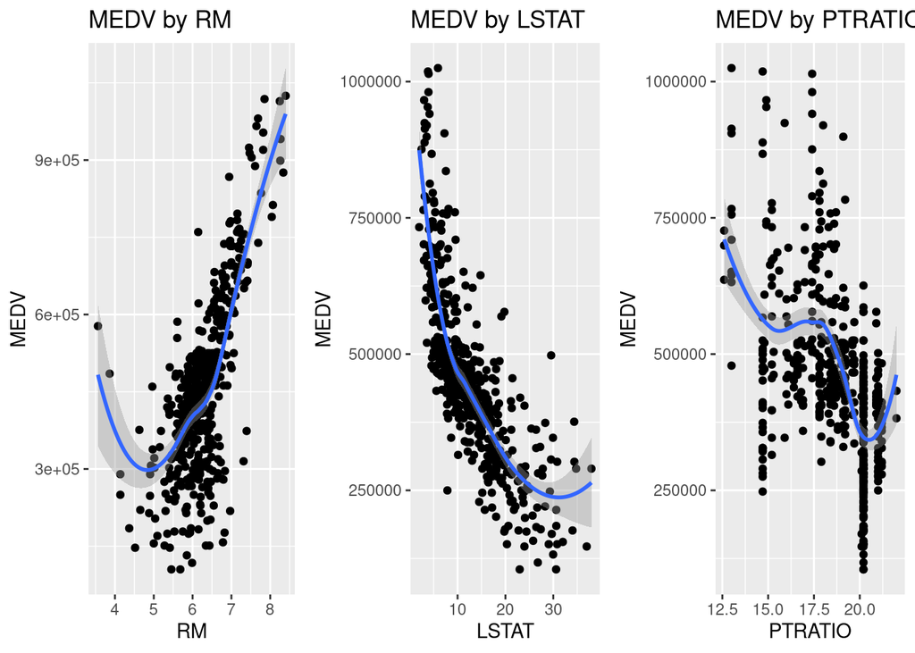

```r
p1 <- qplot(RM, MEDV, data = df, geom = c("point", "smooth")) + ggtitle("MEDV by RM")
p2 <- qplot(LSTAT, MEDV, data = df, geom = c("point", "smooth")) + ggtitle("MEDV by LSTAT")
p3 <- qplot(PTRATIO, MEDV, data = df, geom = c("point", "smooth")) + ggtitle("MEDV by PTRATIO")

multiplot(p1, p2, p3, cols=3)
```

### Observation

- In the first plot, we observe that RM and MEDV are positively correlated, meaning the more the value of RM, the more will be the value of MEDV. It is pretty evident that with increase in the number of rooms, the price of the house will increase.
- In the second plot, we observe that LSTAT and MEDV are negatively correlated, meaning the more the value of LSTAT, the less will be the value of MEDV. It is pretty evident that with increase in the lower class homeowners, then more likely very expensive real estate owners will not build their housing complexes in that region as most of the people will not be able to afford it.
- In the third plot, we observe that PTRATIO and MEDV are negatively correlated, meaning the more the value of PTRATIO, the less will be the value of MEDV. It is pretty evident that with increase in the students to teachers ratio, teachers will not be able to attend to students individually everytime and hence this may affect the education of students. So regions with a low PTRATIO will have higher prices for houses.
- To summarize, the correlation between the feature variables and the target variable is as follows:
1. Negative correlation: LSTAT, PTRATIO
2. Positive correlation: RM

## Outlier Treatment

```r
# Step 1: Store  the variables to be transformed in a new dataframe, so as to not affect the original dataset
variables_to_transform <- df[]

# Let us take a look at the number of rows and columns in this selection
message("columns = ", ncol(variables_to_transform), "; rows = ", nrow(variables_to_transform))
```

```
## columns = 4; rows = 489
```

```r
# Step 2: create a table of same dimension as the variables_to_transform and initialize it with zero
data.transformed <- matrix(0, nrow(variables_to_transform), ncol(variables_to_transform))
```

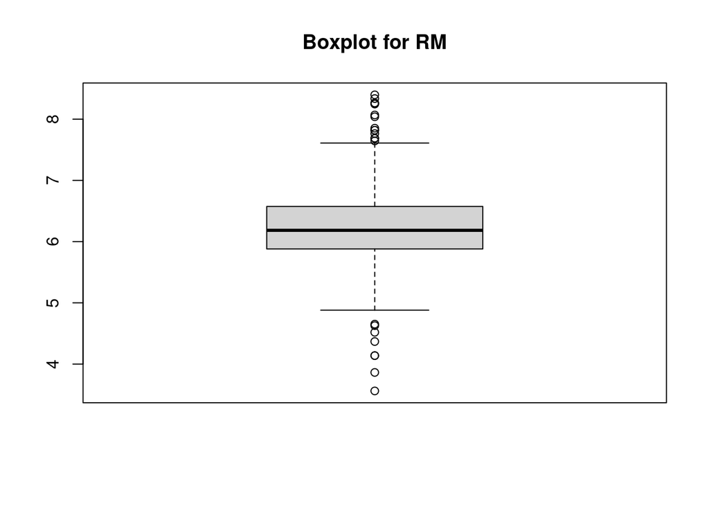

```r
# Step 3:
# Function to remove outliers using IQR method
remove_outliers <- function(x) {
  q <- quantile(x, c(0.25, 0.75))
  iqr <- q[2] - q[1]
  lower_bound <- q[1] - 1.5 * iqr
  upper_bound <- q[2] + 1.5 * iqr
  x_filtered <- x[x >= lower_bound & x <= upper_bound]
  return(x_filtered)
}

# Step 4: Analyse each column and treat outliers. Store the output in new matrix:

#Creating boxplots to view the outliers in the column RM prior to treatment
boxplot(df$"RM",main="Boxplot for RM")
```

```r
# Measure skewness
skewness_value <- skewness(df$"RM")
message("Skewness for RM:", skewness_value, "\n")
```

```
## Skewness for RM:0.0813148648441341
```

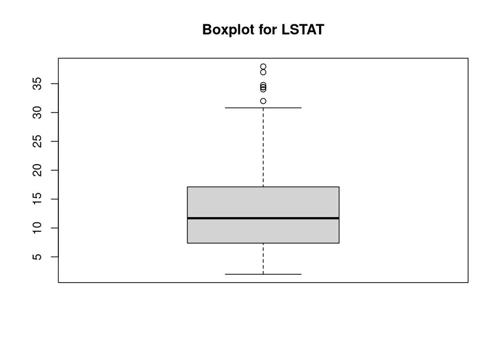

```r
# Remove outliers and update the data.transformed matrix
data.transformed[,1] <- NA
data.transformed[,1] <- ifelse(is.na(data.transformed[,1]), remove_outliers(df$"RM"), data.transformed[,1])


#Creating boxplots to view the outliers in the column LSTAT prior to treatment
boxplot(df$"LSTAT",main="Boxplot for LSTAT")
```

```r
# Measure skewness
skewness_value <- skewness(df$"LSTAT")
message("Skewness for LSTAT:", skewness_value, "\n")
```

```
## Skewness for LSTAT:0.902780659016705
```

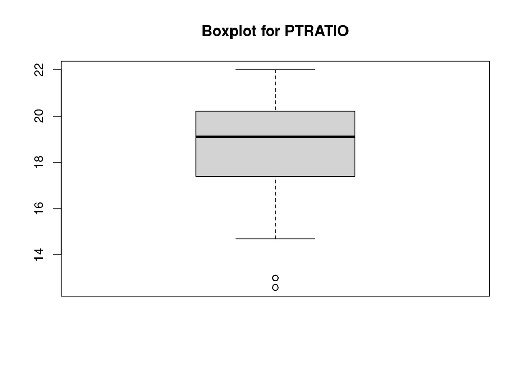

```r
# Remove outliers
data.transformed[,2] <- NA
data.transformed[,2] <- ifelse(is.na(data.transformed[,2]), remove_outliers(df$"LSTAT"), data.transformed[,2])


#Creating boxplots to view the outliers in the column PTRATIO prior to treatment
boxplot(df$"PTRATIO",main="Boxplot for PTRATIO")
```

```r
# Measure skewness
skewness_value <- skewness(df$"PTRATIO")
message("Skewness for PTRATIO:", skewness_value, "\n")
```

```
## Skewness for PTRATIO:-0.818058426074937
```

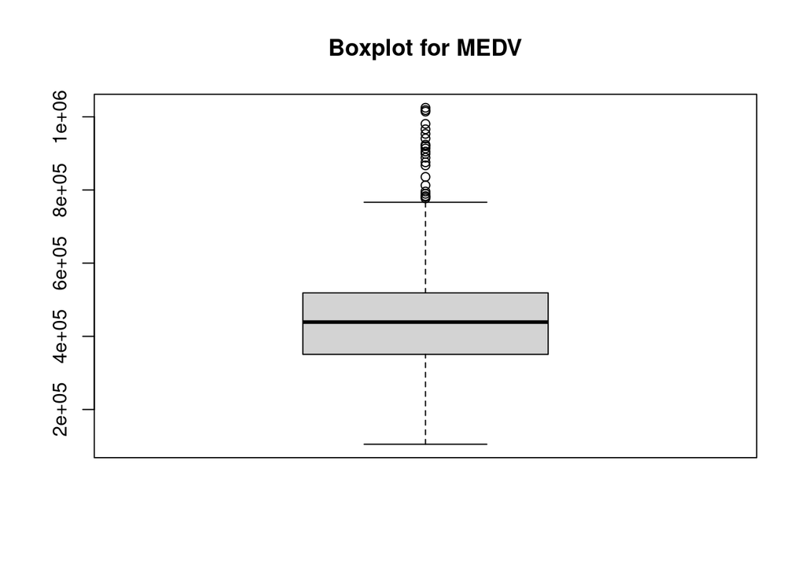

```r
# Remove outliers
data.transformed[,3] <- NA
data.transformed[,3] <- ifelse(is.na(data.transformed[,3]), remove_outliers(df$"PTRATIO"), data.transformed[,3])


#Creating boxplots to view the outliers in the column MEDV prior to treatment
boxplot(df$"MEDV",main="Boxplot for MEDV")
```

```r
# Measure skewness
skewness_value <- skewness(df$"MEDV")
message("Skewness for MEDV:", skewness_value, "\n")
```

```
## Skewness for MEDV:0.772702719634981
```

```r
# Remove outliers
data.transformed[,4] <- NA
data.transformed[,4] <- ifelse(is.na(data.transformed[,4]), remove_outliers(df$"MEDV"), data.transformed[,4])
```

## Normalizing the Data

Judging by plots generated above, we would like to negatively transform some of our feature variables (LSTAT, PTRATIO), so that the effect of negative correlation is removed.

Apart from this, we would like to normalize the all the variables (RM, LSTAT, PTRATIO, MEDV) as well.

```r
# Defining simple data transformation functions:

# 1. Min-Max transformation
min_max_transform <- function(x, input_data=x){
  min = min(input_data)
  max = max(input_data)
  mm_x = 1 * ((x - min)/(max - min))
}

# 2. Negative Min-Max Transformation
# The below negation function is taking care of scaling as well
negative_min_max_transform <- function(x, input_data=x){
  min = min(input_data)
  max = max(input_data)
  t_x = 1 - (x - min)/(max - min)
}
```

```r
# Applying data transformation function to the outlier-treated columns:
# Col #1: RM, Col #2 : LSTAT, Col #3: PTRATIO, Col #4: MEDV

data.transformed[,1]=min_max_transform(data.transformed[,1])
data.transformed[,2]=negative_min_max_transform(data.transformed[,2])
data.transformed[,3]=negative_min_max_transform(data.transformed[,3])
data.transformed[,4]=min_max_transform(data.transformed[,4])
```

# Fitting Aggregation Functions to data:

The fitting functions in AggWaFit718.r takes in data as its input where it treats the last column as our intended output values, and the other columns as input values. It then attempts to find weights for each input by minimising the error measure, which requires optimisation knowledge.

We have discussed these aggregation functions in the previous week. We will now apply them to our dataset.

Note: For all the functions defined in the file: It generates two files output1.txt and stats1.txt in your working directory, the name of output files can be changed. The last column in output1.txt is the fitted value

```r
# Installing the lpSolve package
install.packages("lpSolve")
# Calling the lpSolve library
library(lpSolve)


# Reading the AggWaFit718.R file to use its functions
source("AggWaFit718.R")
```

### Weighted Arithmetic Mean

```r
# find the weights for a weighted arithmetic mean
fit.QAM(data.transformed, output.1="AM-output.txt",stats.1="AM-stats.txt", g=AM, g.inv=invAM) # by default, it uses AM
```

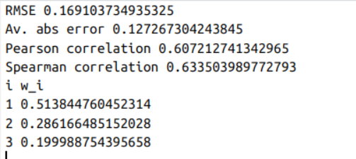

### Weighted power means with p=0.5, the outputs files are PM05output1.txt and PM05stats1.txt

```r
fit.QAM(data.transformed,output.1="PM05output1.txt",stats.1="PM05stats1.txt", g=PM05,g.inv = invPM05) # p = 0.5
```

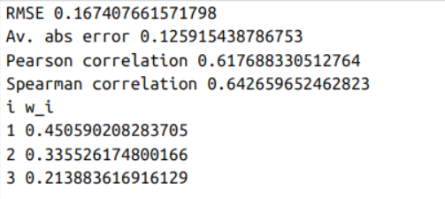

### Weighted power means with p=2, the outputs files are QMoutput1.txt and QMstats1.txt

```r
fit.QAM(data.transformed,output.1="QMoutput1.txt",stats.1="QMstats1.txt",g=QM,g.inv = invQM) # p = 2
```

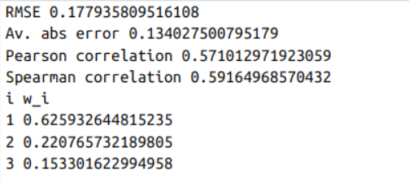

# Weighted geometric means, the outputs files are GMoutput1.txt and GMstats1.txt

```r
fit.QAM(data.transformed,output.1="GMoutput1.txt",stats.1="GMstats1.txt",g=GMa,g.inv = invGMa) # GM
```

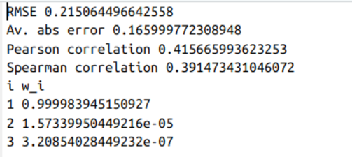

# OWA, the outputs files are OWAoutput1.txt and OWAstats1.txt

```r
fit.OWA(data.transformed,"OWAoutput1.txt","OWAstats1.txt") # OWA
```

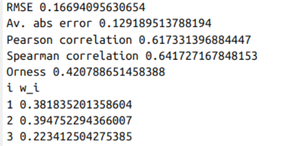